# Tarea 5

- Estudiante: Brian Durán

# Metodos supervisados

Librerias

```r
library(caTools)
library(rpart)
library(randomForest)
library(visdat)
library(dplyr)
```

```r
library(tibble)
library(rpart.plot)
library(GGally)
```

1. Desarolle el Análisis del Problema

Este conjunto de datos incluye descripciones de muestras hipotéticas correspondientes a 23 especies de hongos branquiales en el hongo de la familia Agaricus y Lepiota extraídas de la guía de campo de la Sociedad Audubon de hongos de América del Norte (1981). Cada especie se identifica como definitivamente comestible, definitivamente venenosa o de comestibilidad desconocida y no se recomienda. Esta última clase se combinó con la venenosa. Dentro de la especificaciones de los datos (archivo *agaricus-lepiota.names* ubicado dentro del directorio) se puede ver que existen una serie de reglas complejas para definir si un hongo es comestible o venenoso, no hay forma sencilla o directa para determinar la clase de una muestra. A continuación se llevará a cabo el procesamiento de los datos para luego utilizar 3 modelos sobre los mismos y elaborar una conclusión. Se utilizara regresión logística, arboles de decisión y bosques aleatorios para el desarrollo del problema.

Fuente del dataset: https://archive.ics.uci.edu/ml/machine-learning-databases/mushroom/agaricus-lepiota.data

2. Cargue el archivo agaricus_lepiota.data.csv en una variable

```r
mushrooms_col_names <- c("class", "cap_shape", "cap_surface", "cap_color", "bruises", "odor", "gill_attachment", "gill_spacing", "gill_size", "gill_color", "stalk_shape", "stalk_root", "stalk_surface_above_ring", "stalk_surface_below_ring", "stalk_color_above_ring", "stalk_color_below_ring", "veil_type", "veil_color", "ring_number", "ring_type", "spore_print_color", "population", "habitat")

mushrooms_data <- read.csv("agaricus_lepiota_expanded.csv", header=FALSE, na.strings = '?')

colnames(mushrooms_data) <- mushrooms_col_names
```

3. Desarolle el Entendimiento de los Datos

El conjunto de datos específicado como **fuente** no contaba con nada más que observaciones, los encabezados fueron tomados del archivo *agaricus-lepiota.names* localizado en el mismo directorio donde se ubica *agaricus-lepiota.data*. Luego de analizar los datos y las carácterísticas a evaluar, se puede ver que el archivo cuenta con 23 columnas, de las cuales, la primer columna corresponde a la clase a la cual pertenece la observación (comestible o venenoso) y el resto a 22 carácterísticas que permitieron determinar la clasificación del hongo. Además por razones de una mejor comprensión del ejercicio se decidio usar el archivo **expanded** para el entendimiento de los datos y las conclusiones, el cual contiene el mismo conjunto de observaciones que *agaricus-lepiota.data*, pero con nombres completos para las características.

```r
head(mushrooms_data)
```

```
##    class cap_shape cap_surface cap_color bruises   odor gill_attachment
## 1 EDIBLE    CONVEX      SMOOTH     WHITE BRUISES ALMOND            FREE
## 2 EDIBLE    CONVEX      SMOOTH     WHITE BRUISES ALMOND            FREE
## 3 EDIBLE    CONVEX      SMOOTH     WHITE BRUISES ALMOND            FREE
## 4 EDIBLE    CONVEX      SMOOTH     WHITE BRUISES ALMOND            FREE
## 5 EDIBLE    CONVEX      SMOOTH     WHITE BRUISES ALMOND            FREE
## 6 EDIBLE    CONVEX      SMOOTH     WHITE BRUISES ALMOND            FREE
##   gill_spacing gill_size gill_color stalk_shape stalk_root
## 1      CROWDED    NARROW      WHITE    TAPERING    BULBOUS
## 2      CROWDED    NARROW      WHITE    TAPERING    BULBOUS
## 3      CROWDED    NARROW       PINK    TAPERING    BULBOUS
## 4      CROWDED    NARROW       PINK    TAPERING    BULBOUS
## 5      CROWDED    NARROW      BROWN    TAPERING    BULBOUS
## 6      CROWDED    NARROW      BROWN    TAPERING    BULBOUS
##   stalk_surface_above_ring stalk_surface_below_ring stalk_color_above_ring
```

[output cut: 20 more lines]

Al analizar los valores originales, parecen no haber valores faltantes

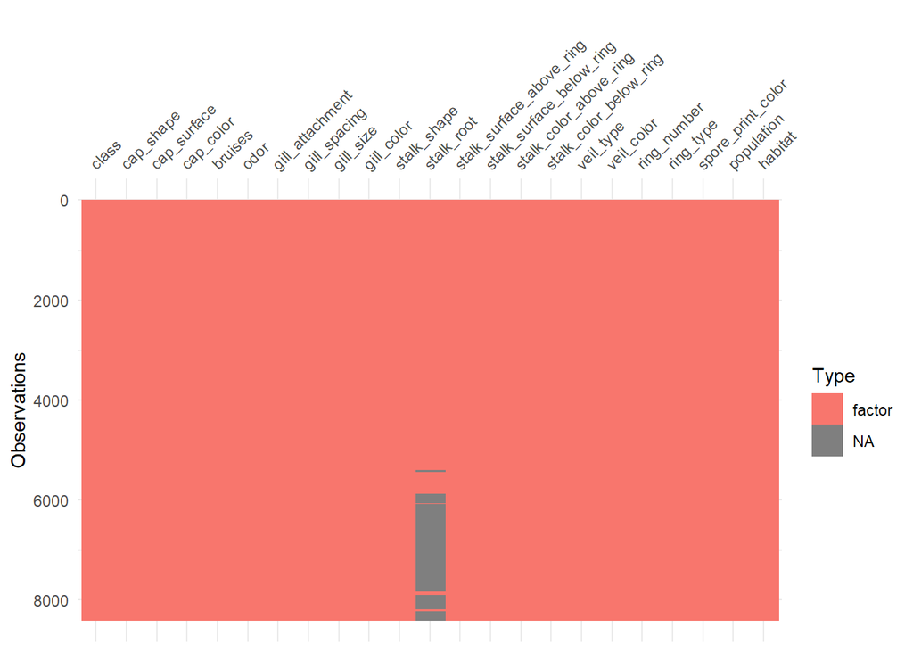

```r
vis_dat(mushrooms_data)
```

Ahora se puede ver con claridad en cuales carácterísticas hay valores faltantes, y parece ser que solo se encuentran dentro de la característica *stalk_root* (“tallo-raíz”).

Veamos cuantas ocurrencias hay por cada clase:

```r
mushrooms_classes <- mushrooms_data %>%
  group_by(class) %>%
  summarise(class_count = length(class))

add_row(mushrooms_classes, class="Total", class_count=length(mushrooms_data$class))
```

```
## # A tibble: 3 x 2
##   class     class_count
##   <fct>           <int>
## 1 EDIBLE           4488
## 2 POISONOUS        3928
## 3 Total            8416
```

4. Utilizando barplot cree un gráfico de los atributos del dataset, observe las correlaciones entre atributos

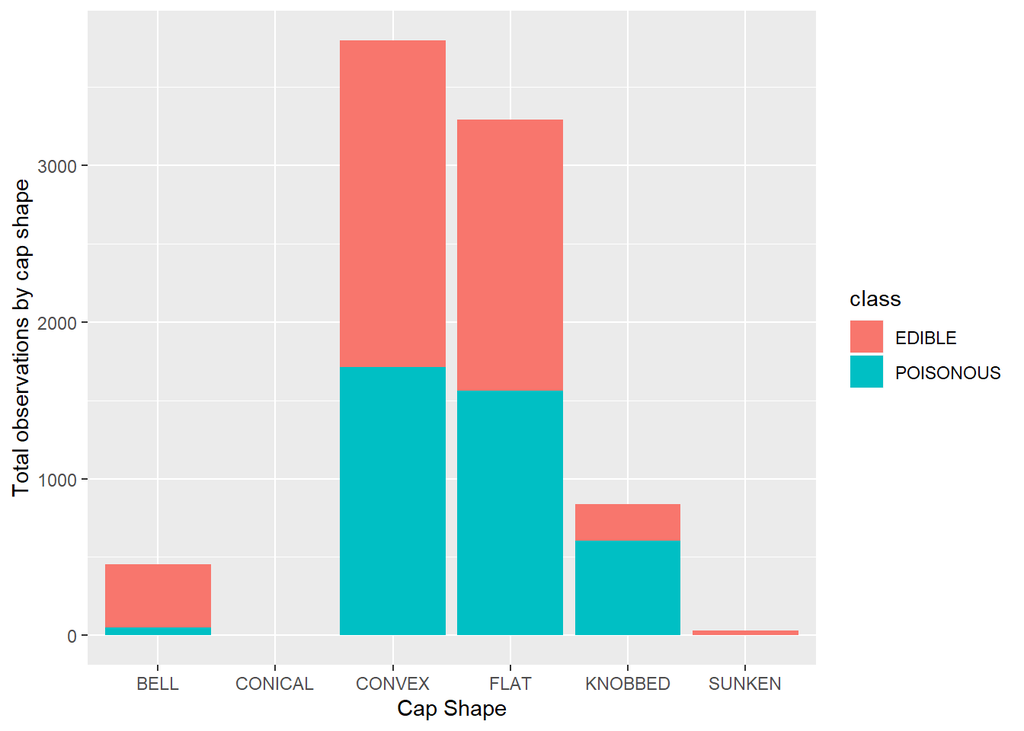

```r
total_observations_by_cap_shape <- mushrooms_data %>%
  group_by(class, cap_shape) %>%
  summarize(total = n())

ggplot(total_observations_by_cap_shape) +
  geom_bar(aes(x = cap_shape, weight = total, fill=class)) +
  labs(x="Cap Shape", y="Total observations by cap shape")
```

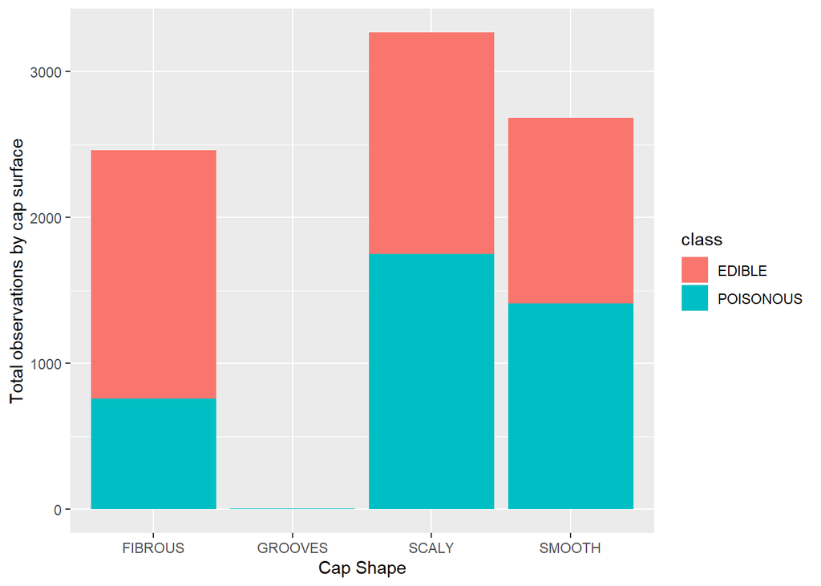

```r
total_observations_by_cap_surface <- mushrooms_data %>%
  group_by(class, cap_surface) %>%
  summarize(total = n())

ggplot(total_observations_by_cap_surface) +
  geom_bar(aes(x = cap_surface, weight = total, fill=class)) +
  labs(x="Cap Shape", y="Total observations by cap surface")
```

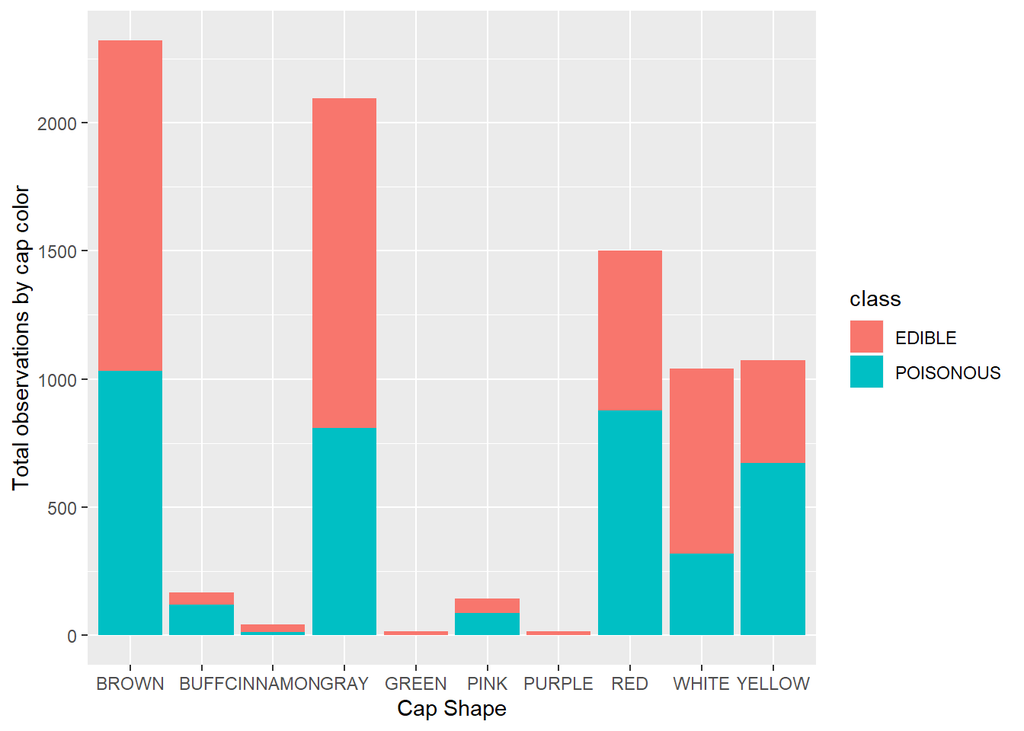

```r
total_observations_by_cap_color <- mushrooms_data %>%
  group_by(class, cap_color) %>%
  summarize(total = n())

ggplot(total_observations_by_cap_color) +
  geom_bar(aes(x = cap_color, weight = total, fill=class)) +
  labs(x="Cap Shape", y="Total observations by cap color")
```

5-6-7. Se desarrollaran 3 métodos supervisados, los cuales serán **árboles de decisión, bosques aleatorios y regresión logística**. Para cada uno de ellos se desarrollará un modelo, se evaluará y se generarán conclusiones.

## Arboles de decisión

### Creación del modelo

Primero se crea el conjunto de datos de entrenamiento y prueba.

```r
set.seed(1)
# Primero se crea un vector de valores lógicos basándose en el data.frame original
splt <- sample.split(mushrooms_data$class, SplitRatio = 0.7)

# Luego se utiliza el set creado anteriormente para dividir la información en un conjunto de datos de entrenamiento y prueba
training_mushrooms <- mushrooms_data[splt,]
testing_mushrooms <- mushrooms_data[!splt,]
```

Ahora comprobamos que todas la observaciones fueron incluidas.

```r
nrow(training_mushrooms) + nrow(testing_mushrooms)
```

```
## [1] 8416
```

Se puede ver que todas las observaciones están presentas.

Ahora se crea el modelo:

```r
decision_tree_model <- rpart(class ~ ., data = training_mushrooms, method =  'class')
```

### Evaluación del modelo

#### Predicciones.

```r
decisition_tree_predictions <- predict(decision_tree_model, newdata = testing_mushrooms, type = 'class')
```

#### Gráfico de los resultados

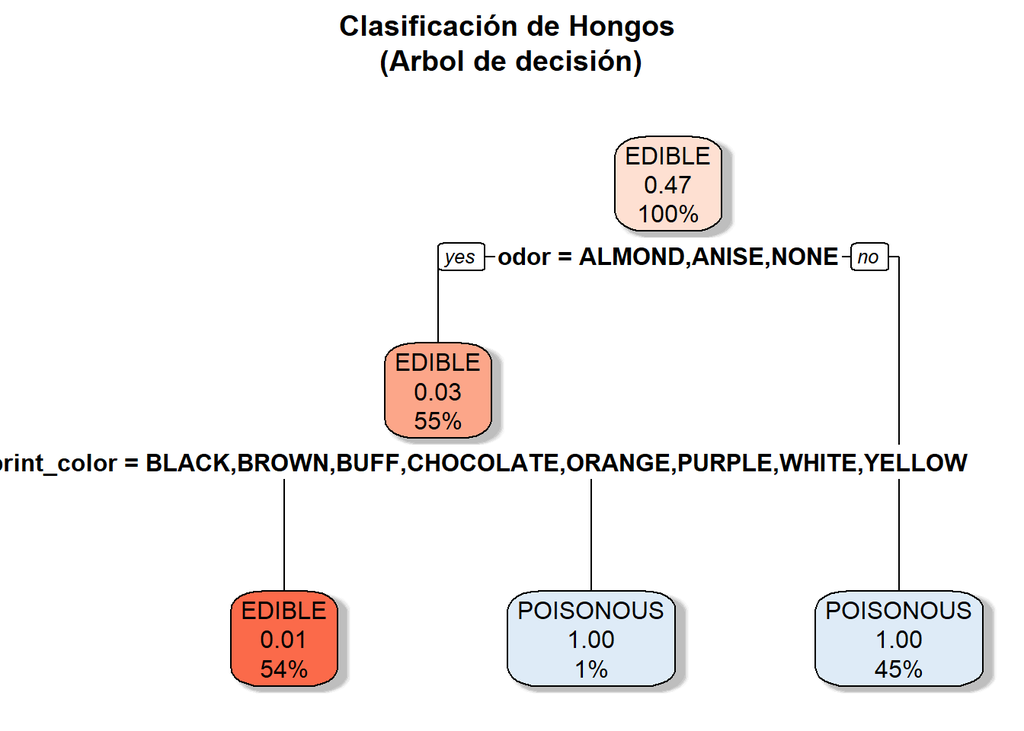

```r
rpart.plot(decision_tree_model,
           shadow.col = "gray",
           box.palette="RdBu",
           main = "Clasificación de Hongos \n(Arbol de decisión)\n")
```

### Conclusiones

#### Matriz de confusión

```r
confusion_matrix_dt <- table(testing_mushrooms$class, decisition_tree_predictions)
confusion_matrix_dt
```

```
##            decisition_tree_predictions
##             EDIBLE POISONOUS
##   EDIBLE      1346         0
##   POISONOUS     17      1161
```

### Métricas a partir de la matriz de confusión

- *Exactitud Total* (observaciones clasificadas apropiadamente) = 99.32%. Hubieron 1346 hongos comestibles y 1161 venenosos clasificados correctamente, mientras que hubieron 17 hongos venenonos clasificados como comestibles.

$$\begin{equation}Exactitud=\frac{VP+VN}{Total}\end{equation}$$

```r
print((confusion_matrix_dt[1,1] + confusion_matrix_dt[2,2]) / sum(confusion_matrix_dt) )
```

```
## [1] 0.9932647
```

- *Sensibilidad* (porcentaje de positivos verdaderos - de las observaciones que realmente son comestibles, ¿cuántas clasificó apropiadamente el modelo?) = 100% (de las 1346 observaciones que son hongos comestibles, 1346 fueron correctamente identificadas).

$$\begin{equation}\text{Sensibilidad}=\frac{VP}{\text{Total Positivos}}\end{equation}$$

```r
print( confusion_matrix_dt[1,1] / (confusion_matrix_dt[1,1] + confusion_matrix_dt[1,2]))
```

```
## [1] 1
```

$$\begin{equation}\text{Precisión}=\frac{VP}{\text{Total clasificados positivos}}\end{equation}$$

```r
print(confusion_matrix_dt[1,1] / (confusion_matrix_dt[1,1] + confusion_matrix_dt[2,1] ))
```

```
## [1] 0.9875275
```

- *Especificidad* (porcentaje de negativos verdaderos - en este caso, de las observaciones que realmente son hongos venenosos, ¿cuántas clasificó apropiadamente el modelo?) = 98.55% (de las 1178 observaciones que son hongos venenosos, 1161 fueron correctamente identificadas).

$$\begin{equation}\text{Especificidad}=\frac{VN}{\text{Total Negativos}}\end{equation}$$

```r
print( confusion_matrix_dt[2,2] / (confusion_matrix_dt[2,1] + confusion_matrix_dt[2,2]))
```

```
## [1] 0.9855688
```

## Bosques aleatorios

### Creación del modelo

```r
set.seed(1)
random_forest_model<- randomForest(class ~ odor + cap_surface + cap_shape + spore_print_color, data = training_mushrooms)
```

### Evaluación del modelo

#### Predicciones

```r
random_forest_predictions <- predict(random_forest_model, newdata = testing_mushrooms, type = 'class')
```

### Conclusiones

#### Matriz de confusión

```r
confusion_matrix_rf <- table(testing_mushrooms$class, random_forest_predictions)
confusion_matrix_rf
```

```
##            random_forest_predictions
##             EDIBLE POISONOUS
##   EDIBLE      1346         0
##   POISONOUS     16      1162
```

- *Exactitud Total* (observaciones clasificadas apropiadamente) = 99.36%. Hubieron 1346 hongos comestibles y 1162 venenosos clasificados correctamente, mientras que hubieron 16 hongos venenonos clasificados como comestibles.

$$\begin{equation}Exactitud=\frac{VP+VN}{Total}\end{equation}$$

```r
print((confusion_matrix_rf[1,1] + confusion_matrix_rf[2,2]) / sum(confusion_matrix_rf) )
```

```
## [1] 0.9936609
```

- *Sensibilidad* (porcentaje de positivos verdaderos - de las observaciones que realmente son comestibles, ¿cuántas clasificó apropiadamente el modelo?) = 100% (de las 1346 observaciones que son hongos comestibles, 1346 fueron correctamente identificadas).

$$\begin{equation}\text{Sensibilidad}=\frac{VP}{\text{Total Positivos}}\end{equation}$$

```r
print( confusion_matrix_rf[1,1] / (confusion_matrix_rf[1,1] + confusion_matrix_rf[1,2]))
```

```
## [1] 1
```

$$\begin{equation}\text{Precisión}=\frac{VP}{\text{Total clasificados positivos}}\end{equation}$$

```r
print(confusion_matrix_rf[1,1] / (confusion_matrix_rf[1,1] + confusion_matrix_rf[2,1] ))
```

```
## [1] 0.9882526
```

- *Especificidad* (porcentaje de negativos verdaderos - en este caso, de las observaciones que realmente son hongos venenosos, ¿cuántas clasificó apropiadamente el modelo?) = 98.64% (de las 1178 observaciones que son hongos venenosos, 1162 fueron correctamente identificadas).

$$\begin{equation}\text{Especificidad}=\frac{VN}{\text{Total Negativos}}\end{equation}$$

```r
print( confusion_matrix_rf[2,2] / (confusion_matrix_rf[2,1] + confusion_matrix_rf[2,2]))
```

```
## [1] 0.9864177
```

## Regresión Logística

### Creación del modelo

```r
logistic_regression_model <- glm(class ~ odor + cap_surface,
data = training_mushrooms,
family = binomial)
```

### Evaluación del modelo

#### Predicciones

```r
logistic_regression_predictions <- predict(logistic_regression_model, newdata = testing_mushrooms, type = 'response')
```

### Conclusiones

#### Matriz de confusión

```r
confusion_matrix_lr <- table(testing_mushrooms$class, logistic_regression_predictions >= 0.5)
confusion_matrix_lr
```

```
##
##             FALSE TRUE
##   EDIBLE     1346    0
##   POISONOUS    31 1147
```

- *Exactitud Total* (observaciones clasificadas apropiadamente) = 98.77%. Hubieron 1346 hongos comestibles y 1147 venenosos clasificados correctamente, mientras que hubieron 31 hongos venenonos clasificados como comestibles.

$$\begin{equation}Exactitud=\frac{VP+VN}{Total}\end{equation}$$

```r
print((confusion_matrix_lr[1,1] + confusion_matrix_lr[2,2]) / sum(confusion_matrix_lr) )
```

```
## [1] 0.9877179
```

- *Sensibilidad* (porcentaje de positivos verdaderos - de las observaciones que realmente son comestibles, ¿cuántas clasificó apropiadamente el modelo?) = 100% (de las 1346 observaciones que son hongos comestibles, 1346 fueron correctamente identificadas).

$$\begin{equation}\text{Sensibilidad}=\frac{VP}{\text{Total Positivos}}\end{equation}$$

```r
print( confusion_matrix_lr[1,1] / (confusion_matrix_lr[1,1] + confusion_matrix_lr[1,2]))
```

```
## [1] 1
```

$$\begin{equation}\text{Precisión}=\frac{VP}{\text{Total clasificados positivos}}\end{equation}$$

```r
print(confusion_matrix_lr[1,1] / (confusion_matrix_lr[1,1] + confusion_matrix_lr[2,1] ))
```

```
## [1] 0.9774873
```

- *Especificidad* (porcentaje de negativos verdaderos - en este caso, de las observaciones que realmente son hongos venenosos, ¿cuántas clasificó apropiadamente el modelo?) = 97.36% (de las 1178 observaciones que son hongos venenosos, 1147 fueron correctamente identificadas).

$$\begin{equation}\text{Especificidad}=\frac{VN}{\text{Total Negativos}}\end{equation}$$

```r
print( confusion_matrix_lr[2,2] / (confusion_matrix_lr[2,1] + confusion_matrix_lr[2,2]))
```

```
## [1] 0.9736842
```